# Demographic Data Labeling

## Motivation

Researchers and data analysts frequently encounter demographic data fields in surveys, questionnaires, and government-furnished data sets. Often, this data is expressed in terms of numerical integers (e.g., 0 for “Male”, 2 for “African American”, 3 for “Some College”). Variable name and value labels foster interpretation of these and other variables that employ integer-valued codes that lack an intrinsic or obvious interpretation. Here, we use a fictional demographic data set from a fictional statistical agency as one way to to illustrate the value and uses of labels (and labelr!).

## Our Fictional Demographic Data

Let’s start by loading labelr.

```r
library(labelr)
```

Now, let’s create a fake “demographic” data.frame, apply labels to it, and do some things with those labels.

`make_demo_data()` (included with labelr) creates fake “demographic” data intended for use in exploring/demonstrating labelr functionality. Here, we’ll create a 1000-observation data.frame.

```r
set.seed(555)
df <- make_demo_data(n = 1000)

head(df)
### >     id age gender raceth edu     x1     x2
### > T-1  1  59      1      4   5 120.25 0.5928
### > N-2  2  56      1      1   2  67.12 0.9116
### > D-3  3  54      1      6   3  79.28 0.6993
### > Q-4  4  46      1      5   4  99.59 0.2243
### > E-5  5  18      1      6   4  90.49 0.0099
### > K-6  6  45      0      2   4  78.55 0.9250
```

## Add VALUE Labels Using `add_val_labs()`

Let’s add value labels for variable “raceth”. Note: max.unique.vals sets an upper limit on the number of unique values a variable may have be considered “value-label-able.” labelr sets an overall upper limit of 5000 unique value labels permissible per variable. If you need more, labelr is not the package for you (but see below discussion of `add_quant_labs()`).

```r
df <- add_val_labs(df,
  vars = "raceth", vals = c(1:7),
  labs = c(
    "White", "Black", "Latino",
    "Asian", "AIAN", "Multi", "Other"
  ),
  max.unique.vals = 10
)
### > Labeling variable --raceth--:
### >      var vals   labs
### > 1 raceth    1  White
### > 2 raceth    2  Black
### > 3 raceth    3 Latino
### > 4 raceth    4  Asian
### > 5 raceth    5   AIAN
### > 6 raceth    6  Multi
### > 7 raceth    7  Other
### > 8 raceth   NA     NA
```

## Add VALUE Labels Using `add_val1()`

Let’s add value labels for variable “gender.” Function `add_val1` allows you to supply the variable name unquoted, provided you are value-labeling only one variable. (Not evident from the above, but `add_val_labs` supports labeling multiple variables at once).

```r
df <- add_val1(
  data = df, gender, vals = c(0, 1, 2),
  labs = c("Male", "Female", "Other"), max.unique.vals = 10
)
### > Labeling variable --gender--:
### >       var vals   labs
### > 9  gender    0   Male
### > 10 gender    1 Female
### > 11 gender    2  Other
### > 12 gender   NA     NA
```

## Add NUMERICAL RANGE Labels Using `add_quant_labs()`

Value labels are intended for categorical variables, such as binary, nominal, or (integer) ordinal variables with limited numbers of distinct categories. Further, value labels are constrained to map one-to-one to distinct values: Any given value label can map to only one distinct value and vice versa.

If you wish to apply a label to a range of values of a numerical variable, such as labeling each value according to the quintile or decile to which it belongs, you can use `add_quant_labs()` (or `add_quant1`) to do so.

Here, we will use `add_quant_labs` to apply quintile range labels to all variables of df that have an “x” in their names (i.e., vars “x1” and “x2”)

```r
df_temp <- add_quant_labs(data = df, vars = "x", qtiles = 5, partial = TRUE)
### > Labeling variable --x1--:
### >    var    vals labs
### > 13  x1  82.976 q020
### > 14  x1  95.238 q040
### > 15  x1 106.142 q060
### > 16  x1 117.524 q080
### > 17  x1  157.98 q100
### > 18  x1      NA   NA
### > Labeling variable --x2--:
### >    var    vals labs
### > 19  x2 0.22404 q020
### > 20  x2 0.41608 q040
### > 21  x2 0.62034 q060
### > 22  x2 0.80538 q080
### > 23  x2  0.9992 q100
### > 24  x2      NA   NA
### > Remember: This command uses partial vars arg matching.
### > Use a more specific vars argument or set partial = FALSE
### > ...if you want to restrict labeling to fewer/more specific variables.

head(use_val_labs(df_temp), 5)
### >     id age gender raceth edu   x1   x2
### > T-1  1  59 Female  Asian   5 q100 q060
### > N-2  2  56 Female  White   2 q020 q100
### > D-3  3  54 Female  Multi   3 q020 q080
### > Q-4  4  46 Female   AIAN   4 q060 q040
### > E-5  5  18 Female  Multi   4 q040 q020
```

As `add_quant_labs` adds those numerical range labels, the console output shows the actual quintile value of the supplied variable (here, “x1” and “x2”) that corresponds to each quintile (range) label. Any value at or below that value (and above the next-lowest quintile) is assigned that quintile label (as the call to `use_val_labs()` shows).

We can use the same function to assign arbitrary, user-specified range labels. Here, we assign labels that differentiate values of “x1” and “x2” that are at or below 100 from values that are at or below 150.

```r
df_temp <- add_quant_labs(
  data = df_temp, vars = "x", vals = c(100, 150),
  partial = TRUE
)
### >
### >   Dropping all value labels from variable --x1--.
### > Labeling variable --x1--:
### >    var vals  labs
### > 19  x1  100 <=100
### > 20  x1  150 <=150
### > 21  x1   NA    NA
### >
### >   Dropping all value labels from variable --x2--.
### > Warning in add_quant_labs(data = df_temp, vars = "x", vals = c(100, 150), :
### >
### > Some of the supplied vals argument values are outside
### > the observed range of var --x2-- values
### > Labeling variable --x2--:
### >    var vals  labs
### > 16  x2  100 <=100
### > 17  x2  150 <=150
### > 18  x2   NA    NA
### > Remember: This command uses partial vars arg matching.
### > Use a more specific vars argument or set partial = FALSE
### > ...if you want to restrict labeling to fewer/more specific variables.

head(use_val_labs(df_temp), 5)
### >     id age gender raceth edu    x1    x2
### > T-1  1  59 Female  Asian   5 <=150 <=100
### > N-2  2  56 Female  White   2 <=100 <=100
### > D-3  3  54 Female  Multi   3 <=100 <=100
### > Q-4  4  46 Female   AIAN   4 <=100 <=100
### > E-5  5  18 Female  Multi   4 <=100 <=100
```

```r
df <- add_quant1(df, x1, qtiles = 5)
### > Labeling variable --x1--:
### >    var    vals labs
### > 13  x1  82.976 q020
### > 14  x1  95.238 q040
### > 15  x1 106.142 q060
### > 16  x1 117.524 q080
### > 17  x1  157.98 q100
### > 18  x1      NA   NA

head(use_val_labs(df), 5)
### >     id age gender raceth edu   x1     x2
### > T-1  1  59 Female  Asian   5 q100 0.5928
### > N-2  2  56 Female  White   2 q020 0.9116
### > D-3  3  54 Female  Multi   3 q020 0.6993
### > Q-4  4  46 Female   AIAN   4 q060 0.2243
### > E-5  5  18 Female  Multi   4 q040 0.0099
```

We’ll preserve the “x1” range labels going forward, keeping “x2” unlabeled.

## Add MANY-TO-ONE VALUE Labels Using `add_m1_lab()`

If you wish to apply a single label to multiple distinct values, this can be done through successive calls to `add_m1_lab()` (or `add1m1()`, if working with a single variable). Here “m1” is shorthand for “many to one.”

Note that each call to `add_m1_lab()` applies a single value label, so,  
multiple calls are needed to apply multiple labels. Here, we illustrate this, applying the label “Some College+” to values 3, 4, or 5 of the variable “edu”, then applying other distinct labels to values 1 and 2, respectively.

```r
df <- add_m1_lab(df, "edu", vals = c(3:5), lab = "Some College+")
### > Labeling variable --edu--:
### >    var vals          labs
### > 19 edu    1             1
### > 20 edu    2             2
### > 21 edu    3 Some College+
### > 22 edu    4 Some College+
### > 23 edu    5 Some College+
### > 24 edu   NA            NA

df <- add_m1_lab(df, "edu", vals = 1, lab = "Not HS Grad")
### > Labeling variable --edu--:
### >    var vals          labs
### > 13 edu    1   Not HS Grad
### > 14 edu    2             2
### > 15 edu    3 Some College+
### > 16 edu    4 Some College+
### > 17 edu    5 Some College+
### > 18 edu   NA            NA

df <- add_m1_lab(df, "edu", vals = 2, lab = "HSG, No College")
### > Labeling variable --edu--:
### >    var vals            labs
### > 13 edu    1     Not HS Grad
### > 14 edu    2 HSG, No College
### > 15 edu    3   Some College+
### > 16 edu    4   Some College+
### > 17 edu    5   Some College+
### > 18 edu   NA              NA

get_val_labs(df)
### >       var    vals            labs
### > 1  gender       0            Male
### > 2  gender       1          Female
### > 3  gender       2           Other
### > 4  gender      NA              NA
### > 5  raceth       1           White
### > 6  raceth       2           Black
### > 7  raceth       3          Latino
### > 8  raceth       4           Asian
### > 9  raceth       5            AIAN
### > 10 raceth       6           Multi
### > 11 raceth       7           Other
### > 12 raceth      NA              NA
### > 13    edu       1     Not HS Grad
### > 14    edu       2 HSG, No College
### > 15    edu       3   Some College+
### > 16    edu       4   Some College+
### > 17    edu       5   Some College+
### > 18    edu      NA              NA
### > 19     x1  82.976            q020
### > 20     x1  95.238            q040
### > 21     x1 106.142            q060
### > 22     x1 117.524            q080
### > 23     x1  157.98            q100
### > 24     x1      NA              NA
```

## Add Variable NAME Labels Using `add_name_labs()`

Now, let’s add (some fairly trivial) variable NAME labels

```r
df <- add_name_labs(df, name.labs = c(
  "age" = "Age in years",
  "raceth" = "Racial/ethnic identity group category",
  "gender" = "Gender identity",
  "edu" = "Highest education level attained",
  "x1" = "Space Invaders reaction time test scores",
  "x2" = "Galaga reaction time test scores"
))
```

## Add a variable “frame label” using `add_frame_lab()`

Finally, we can provide an overall “frame” label, for the data set as a whole. Like the data.frame itself, this frame label is entirely fictional.

```r
df <- add_frame_lab(df, frame.lab = "Demographic and reaction time test score
                    records collected by Royal Statistical Agency of
                    Fictionaslaviaca. Data fictionally collected in the year
                    1987. As published in A. Smithee (1988). Some Fictional Data
                    for Your Amusement. Mad Magazine, 10(1), 1-24.")


get_frame_lab(df)
### >   data.frame
### > 1         df
### >                                                                                                                                                                                                                                                        frame.lab
### > 1 Demographic and reaction time test score records collected by Royal Statistical Agency of Fictionaslaviaca. Data fictionally collected in the year 1987. As published in A. Smithee (1988). Some Fictional Data for Your Amusement. Mad Magazine, 10(1), 1-24.
```

## Get Label Lookup Tables with `get_name_labs()` and `get_val_labs()`

Were we successful in adding our labels? It’s not obvious that we were.

```r
head(df)
### >     id age gender raceth edu     x1     x2
### > T-1  1  59      1      4   5 120.25 0.5928
### > N-2  2  56      1      1   2  67.12 0.9116
### > D-3  3  54      1      6   3  79.28 0.6993
### > Q-4  4  46      1      5   4  99.59 0.2243
### > E-5  5  18      1      6   4  90.49 0.0099
### > K-6  6  45      0      2   4  78.55 0.9250
```

Don’t be so sure. The labels are indeed there, lurking in the background:

```r
get_frame_lab(df)
### >   data.frame
### > 1         df
### >                                                                                                                                                                                                                                                        frame.lab
### > 1 Demographic and reaction time test score records collected by Royal Statistical Agency of Fictionaslaviaca. Data fictionally collected in the year 1987. As published in A. Smithee (1988). Some Fictional Data for Your Amusement. Mad Magazine, 10(1), 1-24.

get_name_labs(df)
### >      var                                      lab
### > 1     id                                       id
### > 2    age                             Age in years
### > 3 gender                          Gender identity
### > 4 raceth    Racial/ethnic identity group category
### > 5    edu         Highest education level attained
### > 6     x1 Space Invaders reaction time test scores
### > 7     x2         Galaga reaction time test scores

get_val_labs(df)
### >       var    vals            labs
### > 1  gender       0            Male
### > 2  gender       1          Female
### > 3  gender       2           Other
### > 4  gender      NA              NA
### > 5  raceth       1           White
### > 6  raceth       2           Black
### > 7  raceth       3          Latino
### > 8  raceth       4           Asian
### > 9  raceth       5            AIAN
### > 10 raceth       6           Multi
### > 11 raceth       7           Other
### > 12 raceth      NA              NA
### > 13    edu       1     Not HS Grad
### > 14    edu       2 HSG, No College
### > 15    edu       3   Some College+
### > 16    edu       4   Some College+
### > 17    edu       5   Some College+
### > 18    edu      NA              NA
### > 19     x1  82.976            q020
### > 20     x1  95.238            q040
### > 21     x1 106.142            q060
### > 22     x1 117.524            q080
### > 23     x1  157.98            q100
### > 24     x1      NA              NA
```

## Subset Our Lookup Tables to Streamline Output

The above commands return data.frames, and we can be more selective about what they return, if we’re interested in only certain variables.

```r
get_name_labs(df, "gender")
### >      var             lab
### > 1 gender Gender identity

get_val_labs(df, "gender")
### >      var vals   labs
### > 1 gender    0   Male
### > 2 gender    1 Female
### > 3 gender    2  Other
### > 4 gender   NA     NA
```

## “Back up” Label Attributes Using `get_all_lab_atts()`

We can save both sets of labels in an external object (a list), as a backup.

Why would we want to do this? Because certain R functions may silently discard our labels. Having them “backed up” (i.e., assigned to some other object) helps us recover quickly from such setbacks.

```r
zlab.df <- get_all_lab_atts(df)
```

## Strip away All Label Attributes Using `strip_labs()`

To simulate such a setback, let’s strip away the labels ourselves.

```r
df <- strip_labs(df)
get_all_lab_atts(df) # nothing there
### > named list()
```

They’re gone!

## Restore All Label Attributes Using `add_lab_atts()`

```r
df <- add_lab_atts(df, zlab.df)
get_all_lab_atts(df)
### > $frame.lab
### > [1] "Demographic and reaction time test score records collected by Royal Statistical Agency of Fictionaslaviaca. Data fictionally collected in the year 1987. As published in A. Smithee (1988). Some Fictional Data for Your Amusement. Mad Magazine, 10(1), 1-24."
### >
### > $name.labs
### >                                         id
### >                                       "id"
### >                                        age
### >                             "Age in years"
### >                                     gender
### >                          "Gender identity"
### >                                     raceth
### >    "Racial/ethnic identity group category"
### >                                        edu
### >         "Highest education level attained"
### >                                         x1
### > "Space Invaders reaction time test scores"
### >                                         x2
### >         "Galaga reaction time test scores"
### >
### > $val.labs.gender
### >        0        1        2       NA
### >   "Male" "Female"  "Other"     "NA"
### >
### > $val.labs.raceth
### >        1        2        3        4        5        6        7       NA
### >  "White"  "Black" "Latino"  "Asian"   "AIAN"  "Multi"  "Other"     "NA"
### >
### > $val.labs.edu
### >                 1                 2                 3                 4
### >     "Not HS Grad" "HSG, No College"   "Some College+"   "Some College+"
### >                 5                NA
### >   "Some College+"              "NA"
### >
### > $val.labs.x1
### >  82.976  95.238 106.142 117.524  157.98      NA
### >  "q020"  "q040"  "q060"  "q080"  "q100"    "NA"
```

Phew! They’re back.

## Overlay Value Labels with `use_val_labs()` and `with_val_labs()`

We can overlay labels in place of values if we wish to view the former.

```r
head(use_val_labs(df), 5)
### >     id age gender raceth             edu   x1     x2
### > T-1  1  59 Female  Asian   Some College+ q100 0.5928
### > N-2  2  56 Female  White HSG, No College q020 0.9116
### > D-3  3  54 Female  Multi   Some College+ q020 0.6993
### > Q-4  4  46 Female   AIAN   Some College+ q060 0.2243
### > E-5  5  18 Female  Multi   Some College+ q040 0.0099
```

We can use with()-like non-standard evaluation, which is helpful in a few limited cases. Note how `with_val_labs` behaves below.

```r
with(df, table(gender, raceth))
### >       raceth
### > gender  1  2  3  4  5  6  7
### >      0 83 66 62 65 64 68 61
### >      1 70 74 79 56 83 69 64
### >      2  3  7  3  6  8  3  6

with_val_labs(df, table(gender, raceth))
### >         raceth
### > gender   AIAN Asian Black Latino Multi Other White
### >   Female   83    56    74     79    69    64    70
### >   Male     64    65    66     62    68    61    83
### >   Other     8     6     7      3     3     6     3

with(use_val_labs(df), table(gender, raceth))
### >         raceth
### > gender   AIAN Asian Black Latino Multi Other White
### >   Female   83    56    74     79    69    64    70
### >   Male     64    65    66     62    68    61    83
### >   Other     8     6     7      3     3     6     3
```

A more compact alias for `use_val_labs()` is available: `uvl()`. When used in conjunction with descriptive functions from Base R or external packages, `uvl()` offers more interpretable output.

```r
# xtabs typical output
xtabs(~raceth, data = df)
### > raceth
### >   1   2   3   4   5   6   7
### > 156 147 144 127 155 140 131

# with df wrapped in `uvl()` or `use_val_labs()`
xtabs(~raceth, data = uvl(df))
### > raceth
### >   AIAN  Asian  Black Latino  Multi  Other  White
### >    155    127    147    144    140    131    156
```

See also `tabl()`.

```r
# `collapse::qsu()`
# with labels "off" (i.e., using regular values of "raceth" as by var)
by_demog_val <- collapse::qsu(df, cols = c("x2"), by = ~raceth)
by_demog_val
### >      N    Mean      SD     Min     Max
### > 1  156  0.5067  0.2696  0.0018  0.9966
### > 2  147  0.4922  0.2755  0.0041  0.9951
### > 3  144  0.4951   0.299  0.0172  0.9992
### > 4  127  0.5461  0.2873   0.006  0.9885
### > 5  155  0.5476  0.2995  0.0076   0.994
### > 6  140  0.5163  0.2798  0.0099  0.9915
### > 7  131  0.5132  0.2786  0.0014  0.9918

# with labels "on" (i.e., using labels, thanks to `uvl()` aka `use_val_labs()`)
by_demog_lab <- collapse::qsu(uvl(df), cols = c("x2"), by = ~raceth)
by_demog_lab
### >           N    Mean      SD     Min     Max
### > AIAN    155  0.5476  0.2995  0.0076   0.994
### > Asian   127  0.5461  0.2873   0.006  0.9885
### > Black   147  0.4922  0.2755  0.0041  0.9951
### > Latino  144  0.4951   0.299  0.0172  0.9992
### > Multi   140  0.5163  0.2798  0.0099  0.9915
### > Other   131  0.5132  0.2786  0.0014  0.9918
### > White   156  0.5067  0.2696  0.0018  0.9966
```

Likewise, `wvl()` serves as a compact alias for `with_val_labs()`.

```r
wvl(df, table(gender, raceth)) # compact alias for with_val_labs
### >         raceth
### > gender   AIAN Asian Black Latino Multi Other White
### >   Female   83    56    74     79    69    64    70
### >   Male     64    65    66     62    68    61    83
### >   Other     8     6     7      3     3     6     3
```

## Overlay Name Labels with `with_name_labs()`

We can use `with_name_labs()` (or alias `wnl()`) to overlay name labels in place column names in various expressions. Note here that our arguments are in terms of column names, but the output is in terms of the corresponding name labels.

```r
# verify that we still have name labels
get_name_labs(df)
### >      var                                      lab
### > 1     id                                       id
### > 2    age                             Age in years
### > 3 gender                          Gender identity
### > 4 raceth    Racial/ethnic identity group category
### > 5    edu         Highest education level attained
### > 6     x1 Space Invaders reaction time test scores
### > 7     x2         Galaga reaction time test scores

# demo wnl() (note that with_name_labs() will achieve same result)
wnl(df, xtabs(x1 ~ gender)) # data arg always goes first, followed by experession
### > Gender identity
### >        0        1        2
### > 46790.57 50012.94  3588.85

wnl(df, aov(x1 ~ gender)) # data arg always goes first, followed by experession
### > Call:
### >    aov(formula = `Space Invaders reaction time test scores` ~ `Gender identity`)
### >
### > Terms:
### >                 `Gender identity` Residuals
### > Sum of Squares              226.5  403242.8
### > Deg. of Freedom                 1       998
### >
### > Residual standard error: 20.10102
### > Estimated effects may be unbalanced

wnl(df, lm(x2 ~ gender * raceth + age))
### >
### > Call:
### > lm(formula = `Galaga reaction time test scores` ~ `Gender identity` *
### >     `Racial/ethnic identity group category` + `Age in years`)
### >
### > Coefficients:
### >                                               (Intercept)
### >                                                 0.5439910
### >                                         `Gender identity`
### >                                                -0.0533033
### >                   `Racial/ethnic identity group category`
### >                                                -0.0023013
### >                                            `Age in years`
### >                                                -0.0003929
### > `Gender identity`:`Racial/ethnic identity group category`
### >                                                 0.0126283
```

Base plots without and with name labels “on.”

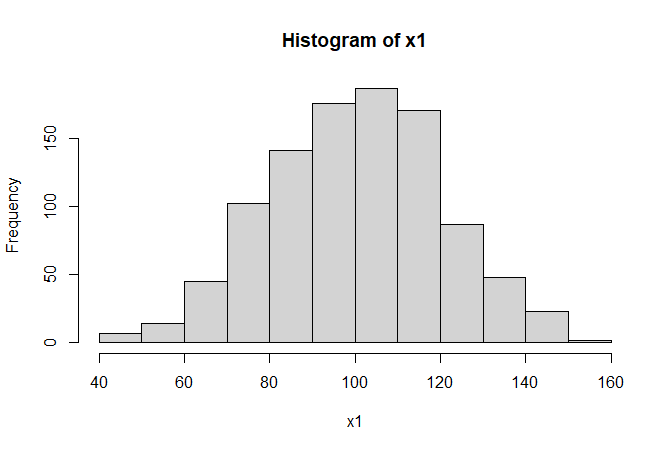

```r
invisible(with(df, hist(x1))) # using with()
```

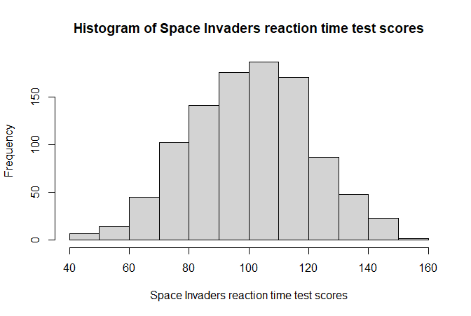

```r
invisible(wnl(df, hist(x1))) # using wnl(); compare to previous histogram
```

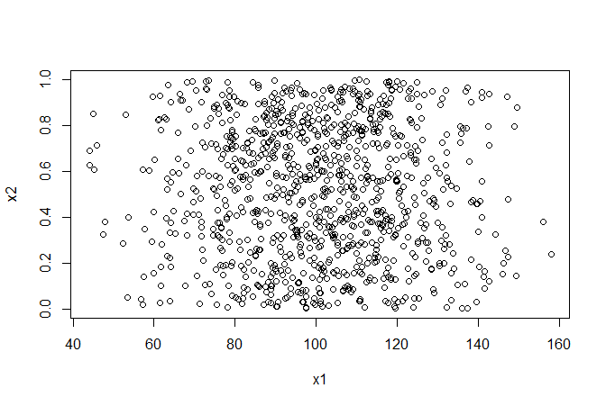

```r
invisible(with(df, plot(x1, x2))) # using with()
```

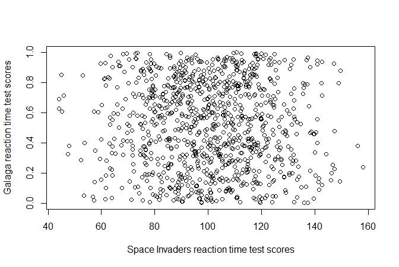

```r
invisible(wnl(df, plot(x1, x2))) # using wnl(); compare to previous scatterplot
```

## Transform Values to Labels Using `use_val_labs()`

Since `use_val_labs()` returns a data.frame, we can use this function to recode all of our value-labeled variables so that the labels become the values in the returned data.frame. Be thoughtful about whether and where you assign the result: this can’t be reversed with a simple command (another good reason to use `get_all_lab_atts`() and `add_lab_atts()`).

```r
df_swap <- use_val_labs(df)

head(df_swap)
### >     id age gender raceth             edu   x1     x2
### > T-1  1  59 Female  Asian   Some College+ q100 0.5928
### > N-2  2  56 Female  White HSG, No College q020 0.9116
### > D-3  3  54 Female  Multi   Some College+ q020 0.6993
### > Q-4  4  46 Female   AIAN   Some College+ q060 0.2243
### > E-5  5  18 Female  Multi   Some College+ q040 0.0099
### > K-6  6  45   Male  Black   Some College+ q020 0.9250
```

## Add Labels Columns Using `add_lab_cols()`

Less destructively, we can add label columns to our data.frame while retaining the values columns.

```r
df_plus <- add_lab_cols(df)

head(df_plus[c("raceth", "raceth_lab", "gender", "gender_lab")])
### >     raceth raceth_lab gender gender_lab
### > T-1      4      Asian      1     Female
### > N-2      1      White      1     Female
### > D-3      6      Multi      1     Female
### > Q-4      5       AIAN      1     Female
### > E-5      6      Multi      1     Female
### > K-6      2      Black      0       Male
```

## Show Select Rows Using `headl()`, `taill()`, `somel()`

Base R includes the `head()` and `tail()` functions, which allow you to show the first n or last n rows of a data.frame. The car package offers a similar function called `some()`, which allows you to show a random n rows of a data.frame.

labelr provides versions of these functions that will display value labels in place of values (akin to `use_val_labs()`). Below, each of the three standard functions is demonstrated, followed by its labelr counterpart.

```r
head(df, 5) # Base R function utils::head()
### >     id age gender raceth edu     x1     x2
### > T-1  1  59      1      4   5 120.25 0.5928
### > N-2  2  56      1      1   2  67.12 0.9116
### > D-3  3  54      1      6   3  79.28 0.6993
### > Q-4  4  46      1      5   4  99.59 0.2243
### > E-5  5  18      1      6   4  90.49 0.0099

headl(df, 5) # labelr function headl() (note the "l")
### >     id age gender raceth             edu   x1     x2
### > T-1  1  59 Female  Asian   Some College+ q100 0.5928
### > N-2  2  56 Female  White HSG, No College q020 0.9116
### > D-3  3  54 Female  Multi   Some College+ q020 0.6993
### > Q-4  4  46 Female   AIAN   Some College+ q060 0.2243
### > E-5  5  18 Female  Multi   Some College+ q040 0.0099

tail(df, 5) # Base R function utils::tail()
### >          id age gender raceth edu     x1     x2
### > Z-996   996  63      0      1   4  92.36 0.0447
### > S-997   997  18      0      4   4 147.40 0.2252
### > K-998   998  45      0      5   2 106.87 0.1610
### > I-999   999  46      1      4   2 119.13 0.7666
### > H-1000 1000  68      0      6   5  70.38 0.5123

taill(df, 5) # labelr function taill() (note the "l")
### >          id age gender raceth             edu   x1     x2
### > Z-996   996  63   Male  White   Some College+ q040 0.0447
### > S-997   997  18   Male  Asian   Some College+ q100 0.2252
### > K-998   998  45   Male   AIAN HSG, No College q080 0.1610
### > I-999   999  46 Female  Asian HSG, No College q100 0.7666
### > H-1000 1000  68   Male  Multi   Some College+ q020 0.5123

car::some(df, 5) # car package function car::some()
### >        id age gender raceth edu     x1     x2
### > H-89   89  24      0      3   3 110.56 0.9992
### > W-425 425  52      1      4   5 108.73 0.0726
### > W-663 663  29      0      6   3  75.43 0.8891
### > M-743 743  28      1      1   4 107.95 0.4214
### > P-983 983  31      0      7   2 111.65 0.8703

somel(df, 5, seed = 1837) # labelr function somel() (note the "l")
### >        id age gender raceth             edu   x1     x2
### > B-407 407  45 Female Latino   Some College+ q020 0.3781
### > O-634 634  33   Male  Asian   Some College+ q060 0.9275
### > F-893 893  56   Male  White   Some College+ q080 0.9966
### > S-361 361  53 Female  Asian HSG, No College q020 0.5263
### > K-452 452  40   Male Latino   Some College+ q100 0.3242
```

Note that `some()` and `somel()` will not return the same random rows.

## “Filter Using Labels” with `flab()`

Similarly, we can filter on value labels, even when they’re “off”.

```r
head(df) # value labels can work for use even when we don't see them
### >     id age gender raceth edu     x1     x2
### > T-1  1  59      1      4   5 120.25 0.5928
### > N-2  2  56      1      1   2  67.12 0.9116
### > D-3  3  54      1      6   3  79.28 0.6993
### > Q-4  4  46      1      5   4  99.59 0.2243
### > E-5  5  18      1      6   4  90.49 0.0099
### > K-6  6  45      0      2   4  78.55 0.9250
df1 <- flab(df, raceth == "Asian" & gender == "Female")
### >
### > Remember: Any filtering conditions involving value-labeled variables must be expressed
### > in terms of the (quoted character) value labels, not the variable values themselves.
### >
### > To filter using values (not labels) of value-labeled variables, try, e.g., sfilter().
head(df1)
### >      id age gender raceth edu     x1     x2
### > T-1   1  59      1      4   5 120.25 0.5928
### > D-40 40  60      1      4   4  78.12 0.9885
### > E-67 67  39      1      4   5  98.21 0.6244
### > I-73 73  36      1      4   2  98.42 0.2102
### > V-80 80  27      1      4   4 122.62 0.3137
### > Q-92 92  44      1      4   2 102.40 0.7108
```

## “Subset using labels” with `slab()`

If we also want to streamline which columns are returned, we can switch from `flab()` to `slab()`. Note that `slab()` requires that a filtering condition be passed.

```r
head(slab(df, raceth == "Black" & gender == "Male", gender, raceth), 10)
### >
### > Remember: Any slab() filtering conditions involving value-labeled variables must be expressed
### > in terms of the (quoted character) value labels, not the variable values themselves.
### >
### > To filter using values (not labels) of value-labeled variables, try, e.g., ssubset().
### >       gender raceth
### > K-6        0      2
### > F-22       0      2
### > E-30       0      2
### > O-46       0      2
### > Q-48       0      2
### > F-72       0      2
### > T-117      0      2
### > K-149      0      2
### > M-161      0      2
### > A-167      0      2
```

## Tabulate frequencies with `tabl()`

…in terms of values

```r
head(tabl(df, vars = "raceth"), 20)
### >
### > Note: To filter zero-frequency rows (i.e., un-observed value combinations)
### > set zero.rm = TRUE.
### >   raceth   n
### > 1      1 156
### > 2      5 155
### > 3      2 147
### > 4      3 144
### > 5      6 140
### > 6      7 131
### > 7      4 127
```

…in terms of labels

```r
head(tabl(df, vars = "raceth", labs.on = TRUE), 20)
### >
### > Note: To filter zero-frequency rows (i.e., un-observed value combinations)
### > set zero.rm = TRUE.
### >   raceth   n
### > 1  White 156
### > 2   AIAN 155
### > 3  Black 147
### > 4 Latino 144
### > 5  Multi 140
### > 6  Other 131
### > 7  Asian 127
```

…without specifying variables

```r
head(tabl(df, labs.on = TRUE), 20)
### >
### > Excluding variable --id-- (includes decimals or exceeds max.unique.vals).
### >
### > Excluding variable --age-- (includes decimals or exceeds max.unique.vals).
### >
### > Excluding variable --x2-- (includes decimals or exceeds max.unique.vals).
### >
### > Note: To filter zero-frequency rows (i.e., un-observed value combinations)
### > set zero.rm = TRUE.
### >    gender raceth           edu   x1  n
### > 1    Male  Other Some College+ q020 18
### > 2    Male  White Some College+ q020 14
### > 3    Male  White Some College+ q060 14
### > 4  Female   AIAN Some College+ q020 13
### > 5  Female   AIAN Some College+ q060 13
### > 6  Female Latino Some College+ q040 13
### > 7  Female Latino Some College+ q100 13
### > 8    Male   AIAN Some College+ q040 13
### > 9  Female   AIAN Some College+ q080 12
### > 10 Female  Asian Some College+ q080 12
### > 11 Female  Black Some College+ q060 12
### > 12   Male  Multi Some College+ q020 12
### > 13   Male  Multi Some College+ q100 12
### > 14   Male  White Some College+ q080 12
### > 15 Female Latino Some College+ q020 11
### > 16 Female  White Some College+ q080 11
### > 17   Male  Asian Some College+ q040 11
### > 18   Male  Black Some College+ q040 11
### > 19   Male Latino Some College+ q100 11
### > 20 Female   AIAN Some College+ q040 10
```

…in proportions

```r
head(tabl(df, labs.on = TRUE, prop.digits = 3), 20)
### >
### > Excluding variable --id-- (includes decimals or exceeds max.unique.vals).
### >
### > Excluding variable --age-- (includes decimals or exceeds max.unique.vals).
### >
### > Excluding variable --x2-- (includes decimals or exceeds max.unique.vals).
### >
### > Note: To filter zero-frequency rows (i.e., un-observed value combinations)
### > set zero.rm = TRUE.
### >    gender raceth           edu   x1     n
### > 1    Male  Other Some College+ q020 0.018
### > 2    Male  White Some College+ q020 0.014
### > 3    Male  White Some College+ q060 0.014
### > 4  Female   AIAN Some College+ q020 0.013
### > 5  Female   AIAN Some College+ q060 0.013
### > 6  Female Latino Some College+ q040 0.013
### > 7  Female Latino Some College+ q100 0.013
### > 8    Male   AIAN Some College+ q040 0.013
### > 9  Female   AIAN Some College+ q080 0.012
### > 10 Female  Asian Some College+ q080 0.012
### > 11 Female  Black Some College+ q060 0.012
### > 12   Male  Multi Some College+ q020 0.012
### > 13   Male  Multi Some College+ q100 0.012
### > 14   Male  White Some College+ q080 0.012
### > 15 Female Latino Some College+ q020 0.011
### > 16 Female  White Some College+ q080 0.011
### > 17   Male  Asian Some College+ q040 0.011
### > 18   Male  Black Some College+ q040 0.011
### > 19   Male Latino Some College+ q100 0.011
### > 20 Female   AIAN Some College+ q040 0.010
```

…cross-tab style

```r
head(tabl(df, labs.on = TRUE, wide.col = "gender"), 20)
### >
### > Excluding variable --id-- (includes decimals or exceeds max.unique.vals).
### >
### > Excluding variable --age-- (includes decimals or exceeds max.unique.vals).
### >
### > Excluding variable --x2-- (includes decimals or exceeds max.unique.vals).
### >
### > Note: To filter zero-frequency rows (i.e., un-observed value combinations)
### > set zero.rm = TRUE.
### >    raceth           edu   x1 Male Female Other
### > 1   Other Some College+ q020   18      5     1
### > 2   White Some College+ q020   14      5     0
### > 3   White Some College+ q060   14      5     2
### > 4    AIAN Some College+ q020    6     13     1
### > 5    AIAN Some College+ q060    8     13     0
### > 6  Latino Some College+ q040    8     13     0
### > 7  Latino Some College+ q100   11     13     0
### > 8    AIAN Some College+ q040   13     10     1
### > 9    AIAN Some College+ q080    4     12     3
### > 10  Asian Some College+ q080    5     12     0
### > 11  Black Some College+ q060    9     12     1
### > 12  Multi Some College+ q020   12     10     1
### > 13  Multi Some College+ q100   12     10     0
### > 14  White Some College+ q080   12     11     0
### > 15 Latino Some College+ q020    8     11     2
### > 16  Asian Some College+ q040   11      6     0
### > 17  Black Some College+ q040   11      6     1
### > 18  Black Some College+ q020    9     10     2
### > 19 Latino Some College+ q060   10     10     1
### > 20 Latino Some College+ q080    5     10     0
```